# FORECASTING NATIONAL PARKS VISITS

Quang Duong

2017-08-16

For this problem, we obtained monthly visits data between 2010 and 2016 (source: https://irma.nps.gov/Stats/Reports/National). We also got park-specific data via the NPS API (https://developer.nps.gov/api/index.htm). The aggregated dataset [park_visits.csv]https://d37djvu3ytnwxt.cloudfront.net/assets/courseware/v1/559e68ca8132a107eea309abb699223a/asset-v1:MITx+15.071x+2T2017+type@asset+block/park_visits.csv results in a total of 12 variables and 25587 observations. Each observation contains one record per park per month. Here’s a detailed description of the variables:

- **ParkName**: The full name of the park.
- **ParkType**: The type of the park. For this study we restrict ourselves to the following more frequently visited types: National Battlefield, National Historic Site, National Historical Park, National Memorial, National Monument, National Park, National Recreation Area, and National Seashore.
- **Region**: The region of the park, including Alaska, Intermountain, Midwest, National Capital, Northeast, Pacific West, and Southeast.
- **State**: The abbreviation of the state where the park resides.
- **Year**, **Month**: the year and the month for the visits.
- **lat**, **long**: Latitude and longitude of the park.
- **Cost**: a simple extraction of the park’s entrance fee. Some parks may have multiple levels of entrance fees (differ by transportation methods, age, military status, etc.); for this problem, we only extracted the first available cost information.
- **logVisits**: Natural logarithm of the recreational visits (with one added to the visits to avoid taking logs of zero) to the park in the given year and month.
- **laglogVisits**: the logVisits from last month.

-**laglogVisitsYear**: the logVisits from last year.

Load park_visits.csv into a data frame called visits.

Let’s first look at the visits in July 2016. Subset the observations to this year and month, name it visits2016jul. Work with this data subset for the next three problems.

Which park type has the most number of parks? Which specific park has the most number of visitors?

```r
visits <- read.csv("park_visits.csv")
visits2016jul <- subset(visits, Year==2016 & Month==7)
sort(table(visits2016jul$ParkType))
visits2016jul[which.max(visits2016jul$logVisits),]
```

```
    National Battlefield        National Seashore National Recreation Area
                      10                       10                       15
       National Memorial National Historical Park            National Park
                      28                       42                       57
       National Monument   National Historic Site
                      68                       75
                      ParkName      ParkType     Region State Year Month
11587 Great Smoky Mountains NP National Park Southeast     TN 2016     7
           lat      long cost logVisits laglogVisits laglogVisitsYear
11587 35.60116 -83.50818    0    14.197     14.12603         14.18127
```

## Problem 2 - Relationship Between Region and Visits

Which region has the highest average log visits in July 2016?

```r
sort(tapply(visits2016jul$logVisits, visits2016jul$Region, mean))
```

```
           Alaska          Midwest         Northeast         Southeast
         9.374157          9.747281          9.914755         10.027672
   Intermountain  National Capital      Pacific West
        10.129625         10.293175         10.767849
```

## Problem 3 - Relationship Between Cost and Visits

What is the correlation between entrance fee (the variable cost) and the log visits in July 2016?

```r
cor(visits2016jul$cost, visits2016jul$logVisits)
```

```
[1] 0.4010611
```

## Problem 4 - Time Series Plot of Visits

Let’s now look at the time dimension of the data. Subset the original data (visits) to “Yellowstone NP” only and save as ys. Use the following code to plot the logVisits through the months between 2010 and 2016:

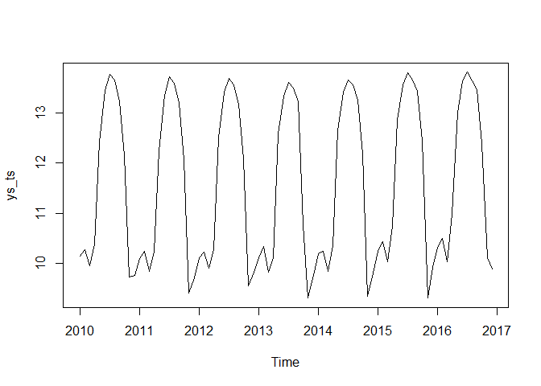

```r
ys <- subset(visits, visits$ParkName=="Yellowstone NP")
ys_ts <- ts(ys$logVisits, start=c(2010,1), freq=12)
plot(ys_ts)
```

## Problem 5 - Missing Values

Note that there are some NA’s in the data - you can run colSums(is.na(visits)) to see the summary.

To deal with the missing values, we will simply remove the observations with the missing values first (there are more sophisticated ways to work with missing values, but for this purpose removing the observations is fine).

```r
visits <- visits[rowSums(is.na(visits))==0,]
str(visits)
```

```
'data.frame':   21855 obs. of  12 variables:
 $ ParkName        : Factor w/ 305 levels "Abraham Lincoln Birthplace NHP",..: 1 1 1 1 1 1 1 1 1 1 ...
 $ ParkType        : Factor w/ 8 levels "National Battlefield",..: 3 3 3 3 3 3 3 3 3 3 ...
 $ Region          : Factor w/ 7 levels "Alaska","Intermountain ",..: 7 7 7 7 7 7 7 7 7 7 ...
 $ State           : Factor w/ 53 levels "AK","AL","AR",..: 19 19 19 19 19 19 19 19 19 19 ...
 $ Year            : int  2011 2011 2011 2011 2011 2011 2011 2011 2011 2011 ...
 $ Month           : int  1 2 3 4 5 6 7 8 9 10 ...
 $ lat             : num  37.6 37.6 37.6 37.6 37.6 ...
 $ long            : num  -85.7 -85.7 -85.7 -85.7 -85.7 ...
 $ cost            : num  0 0 0 0 0 0 0 0 0 0 ...
 $ logVisits       : num  7.88 8.2 8.98 9.87 9.74 ...
 $ laglogVisits    : num  8.32 7.88 8.2 8.98 9.87 ...
 $ laglogVisitsYear: num  8.26 8.55 8.99 9.81 9.87 ...
```

## Problem 6 - Predicting Visits

We are interested in predicting the log visits. Before doing the split, let’s also make Month a factor variable by including the following:

```r
visits$Month <- as.factor(visits$Month)
```

Subset our dataset into a training and a testing set by splitting based on the year: training would contain 2010-2014 years of data, and testing would be 2015-2016 data.

Let’s build now a simple linear regression model “mod” using the training set to predict the log visits. As a first step, we only use the laglogVisits variable (log visits from last month).

```r
library(caTools)
trainSet <- subset(visits, visits$Year<=2014)
testSet <- subset(visits, visits$Year>=2015)
mod <- lm(logVisits ~ laglogVisits, data = trainSet)
summary(mod)
logVisitsPred <- predict(mod, newdata = testSet)
TSS <- sum((testSet$logVisits-mean(trainSet$logVisits))**2)
SSE <- sum((logVisitsPred-testSet$logVisits)**2)
1-SSE/TSS
```

```
Call:
lm(formula = logVisits ~ laglogVisits, data = trainSet)

Residuals:
     Min       1Q   Median       3Q      Max
-12.5265  -0.2866   0.0413   0.3306  12.3876

Coefficients:
             Estimate Std. Error t value Pr(>|t|)
(Intercept)  0.659455   0.028923    22.8   <2e-16 ***
laglogVisits 0.927945   0.003073   301.9   <2e-16 ***
---
Signif. codes:  0 '***' 0.001 '**' 0.01 '*' 0.05 '.' 0.1 ' ' 1

Residual standard error: 0.8817 on 14557 degrees of freedom
Multiple R-squared:  0.8623,    Adjusted R-squared:  0.8623
F-statistic: 9.117e+04 on 1 and 14557 DF,  p-value: < 2.2e-16

[1] 0.8975923
```

## Problem 7 - Add New Variables

We see that the model achieves good predictive power already simply using the previous month’s visits. To see if the other knowledge we have about the parks can improve the model, let’s add these variables in a new model.

The new model would have the following variables:

laglogVisits, laglogVisitsYear, Year, Month, Region, ParkType, and cost

```r
attach(visits)
mod2 <- lm(logVisits ~ laglogVisits + laglogVisitsYear + Year + Month + Region + ParkType + cost, data = trainSet)
summary(mod2)
```

```
Call:
lm(formula = logVisits ~ laglogVisits + laglogVisitsYear + Year +
    Month + Region + ParkType + cost, data = trainSet)

Residuals:
     Min       1Q   Median       3Q      Max
-12.2891  -0.2014   0.0058   0.2293  10.1600

Coefficients:
                                  Estimate Std. Error t value Pr(>|t|)
(Intercept)                      -2.514727  10.909227  -0.231 0.817696
laglogVisits                      0.650702   0.005177 125.682  < 2e-16 ***
laglogVisitsYear                  0.314173   0.005163  60.845  < 2e-16 ***
Year                              0.001244   0.005421   0.230 0.818468
Month2                            0.174008   0.029701   5.859 4.77e-09 ***
Month3                            0.422671   0.029859  14.156  < 2e-16 ***
Month4                            0.276278   0.029842   9.258  < 2e-16 ***
Month5                            0.397868   0.030025  13.251  < 2e-16 ***
Month6                            0.272168   0.030113   9.038  < 2e-16 ***
Month7                            0.255440   0.030234   8.449  < 2e-16 ***
Month8                            0.027959   0.030201   0.926 0.354589
Month9                           -0.024103   0.030090  -0.801 0.423141
Month10                          -0.216415   0.029958  -7.224 5.30e-13 ***
Month11                          -0.177488   0.029782  -5.960 2.59e-09 ***
Month12                          -0.105784   0.029709  -3.561 0.000371 ***
RegionIntermountain               0.207608   0.037177   5.584 2.39e-08 ***
RegionMidwest                     0.207578   0.038276   5.423 5.95e-08 ***
RegionNational Capital            0.205045   0.047474   4.319 1.58e-05 ***
RegionNortheast                   0.234444   0.038089   6.155 7.70e-10 ***
RegionPacific West                0.233219   0.037759   6.177 6.73e-10 ***
RegionSoutheast                   0.249889   0.038567   6.479 9.50e-11 ***
ParkTypeNational Historic Site   -0.048652   0.036199  -1.344 0.178960
ParkTypeNational Historical Park  0.029225   0.037831   0.772 0.439832
ParkTypeNational Memorial         0.028364   0.039655   0.715 0.474452
ParkTypeNational Monument        -0.026587   0.037258  -0.714 0.475489
ParkTypeNational Park             0.019296   0.039394   0.490 0.624276
ParkTypeNational Recreation Area  0.060879   0.045403   1.341 0.179980
ParkTypeNational Seashore         0.034273   0.048327   0.709 0.478218
cost                              0.002859   0.001028   2.780 0.005435 **
---
Signif. codes:  0 '***' 0.001 '**' 0.01 '*' 0.05 '.' 0.1 ' ' 1

Residual standard error: 0.7309 on 14530 degrees of freedom
Multiple R-squared:  0.9056,    Adjusted R-squared:  0.9054
F-statistic:  4977 on 28 and 14530 DF,  p-value: < 2.2e-16
```

```r
logVisitsPred2 <- predict(mod2 , newdata = testSet)
MSE2 <-sum((testSet$logVisits-logVisitsPred2)**2)
1-MSE2/TSS
```

```
[1] 0.937253
```

## Problem 9 - Regression Trees

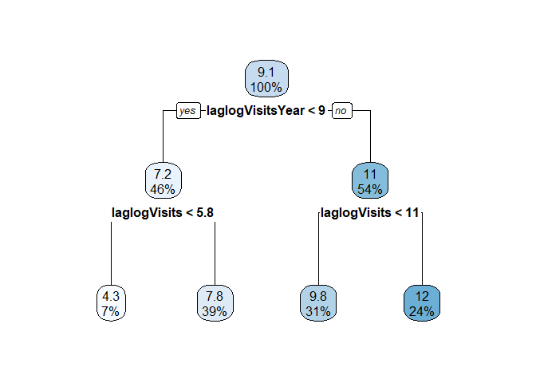

```r
library(rpart)
library(rpart.plot)
regressionTree <- rpart(logVisits ~ laglogVisits + laglogVisitsYear + Year + Month + Region + ParkType + cost, data = trainSet, control = rpart.control(cp=0.05))
rpart.plot(regressionTree)
```

```r
treePred <- predict(regressionTree, newdata = testSet)
MSE3 <- sum((treePred-testSet$logVisits)**2)
1-MSE3/TSS
```

```
[1] 0.7864307
```

## Problem 10 - Regression Trees with CV

The out-of-sample R2 does not appear to be very good under regression trees, compared to a linear regression model. We could potentially improve it via cross validation.

Set seed to 201, run a 10-fold cross-validated cart model, with cp ranging from 0.0001 to 0.005 in increments of 0.0001. What is optimal cp value on this grid?

```r
library(caret)
cpGrid <- expand.grid(.cp=seq(0.0001,0.005,0.0001))
cpControl <- trainControl(method = "cv", number = 10)
set.seed(201)
train(logVisits ~ laglogVisits + laglogVisitsYear + Year + Month + Region + ParkType + cost, data = trainSet, method = "rpart", trControl = cpControl, tuneGrid = cpGrid)
```

```
CART

14559 samples
    7 predictor

No pre-processing
Resampling: Cross-Validated (10 fold)
Summary of sample sizes: 13103, 13104, 13104, 13104, 13103, 13103, ...
Resampling results across tuning parameters:

  cp      RMSE       Rsquared
  0.0001  0.6824665  0.9168443
  0.0002  0.6832780  0.9164079
  0.0003  0.6961230  0.9133423
  0.0004  0.7041688  0.9114099
  0.0005  0.7099198  0.9098579
  0.0006  0.7168504  0.9081713
  0.0007  0.7171821  0.9080820
  0.0008  0.7174752  0.9079824
  0.0009  0.7216888  0.9069412
  0.0010  0.7231863  0.9066095
  0.0011  0.7222898  0.9068415
  0.0012  0.7287608  0.9051884
  0.0013  0.7313513  0.9044773
  0.0014  0.7373103  0.9028499
  0.0015  0.7402810  0.9022136
  0.0016  0.7420392  0.9017781
  0.0017  0.7444753  0.9011110
  0.0018  0.7490792  0.8999663
  0.0019  0.7527415  0.8990181
  0.0020  0.7539970  0.8986590
  0.0021  0.7630471  0.8962758
  0.0022  0.7672991  0.8951408
  0.0023  0.7662689  0.8954253
  0.0024  0.7784386  0.8922262
  0.0025  0.7803700  0.8916827
  0.0026  0.7833136  0.8908534
  0.0027  0.7927014  0.8883374
  0.0028  0.8009630  0.8859230
  0.0029  0.8023107  0.8855479
```

[output cut: 9 more lines]

```
  0.0039  0.8006536  0.8860751
  0.0040  0.8006536  0.8860751
  0.0041  0.8006536  0.8860751
  0.0042  0.8006536  0.8860751
  0.0043  0.8006536  0.8860751
  0.0044  0.8006536  0.8860751
  0.0045  0.8006536  0.8860751
  0.0046  0.8006536  0.8860751
  0.0047  0.8044922  0.8849521
  0.0048  0.8044922  0.8849521
  0.0049  0.8062081  0.8844188
  0.0050  0.8083069  0.8838036

RMSE was used to select the optimal model using  the smallest value.
The final value used for the model was cp = 1e-04.
```

## Problem 11 - Final Regression Tree

Rerun the regression tree on the training data, now using the cp value equal to the one selected in the previous problem

```r
regressionTree2 <- rpart(logVisits ~ laglogVisits + laglogVisitsYear + Year + Month + Region + ParkType + cost, data = trainSet, control = rpart.control(cp=0.0001))
treePred2 <- predict(regressionTree2, newdata = testSet)
MSE4 <- sum((treePred2-testSet$logVisits)**2)
1-MSE4/TSS
```

```
[1] 0.937113
```

## Problem 12 - Random Forest

We can potentially further improve the models by using a random forest. Set seed to 201 again. Train a random forest model with the same set of covariates, and using just default parameters (no need to specify). This may take a few minutes.

```r
library(randomForest)
set.seed(201)
RF <- randomForest(logVisits ~ laglogVisits + laglogVisitsYear + Year + Month + Region + ParkType + cost, data = trainSet)
RFPred <- predict(RF, newdata = testSet)
MSE5 <- sum((RFPred-testSet$logVisits)**2)
1-MSE5/TSS
```

```
[1] 0.947239
```